# analisis_variable_respuesta

Irving, Chuy

2025-02-26

En este documento se realiza un análisis de relaciones con la variable respuesta.

## Distribuciones de las variables

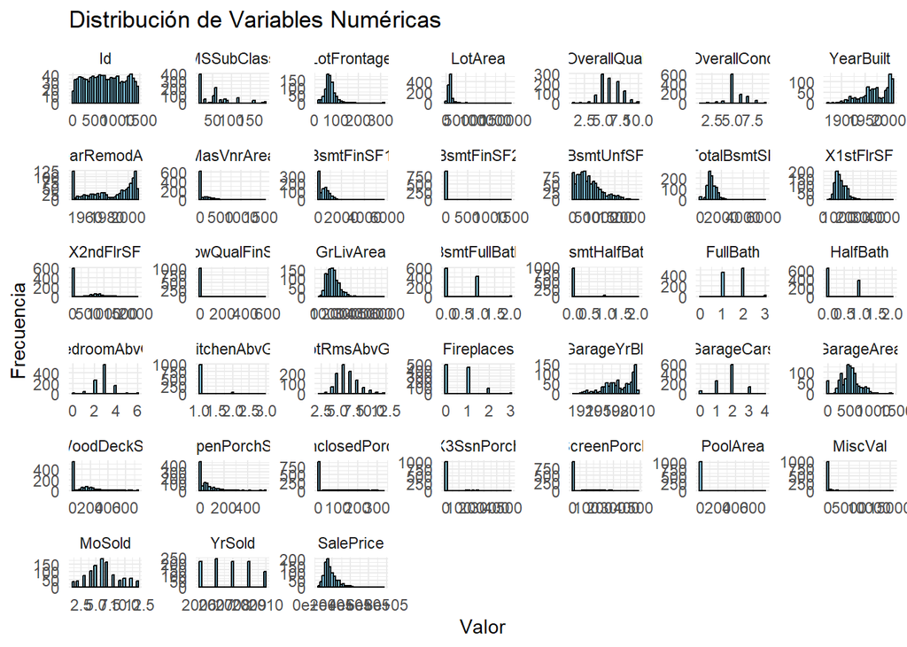

Al analizar las distribuciones de las variables numéricas en tu conjunto de datos, se observan varias características relevantes. Muchas variables, como LotArea y GrLivArea, presentan un sesgo positivo, lo que indica que la mayoría de los valores se concentran en el extremo inferior del rango, con algunos valores atípicos muy altos. Además, hay variables que, aunque parecen numéricas, son en realidad categóricas, como OverallQual y OverallCond, que representan clasificaciones de calidad. También se identifican variables de tiempo, como YearBuilt, que pueden influir en el valor de la propiedad, y algunas variables muestran baja variabilidad, como PoolArea, sugiriendo que podrían no ser predictores significativos del precio de las casas.

Por otro lado, es importante destacar la presencia de valores atípicos en las distribuciones sesgadas, lo que plantea la necesidad de evaluar si estos datos son errores de entrada o representan casos válidos.

## Coeficientes de correlacion

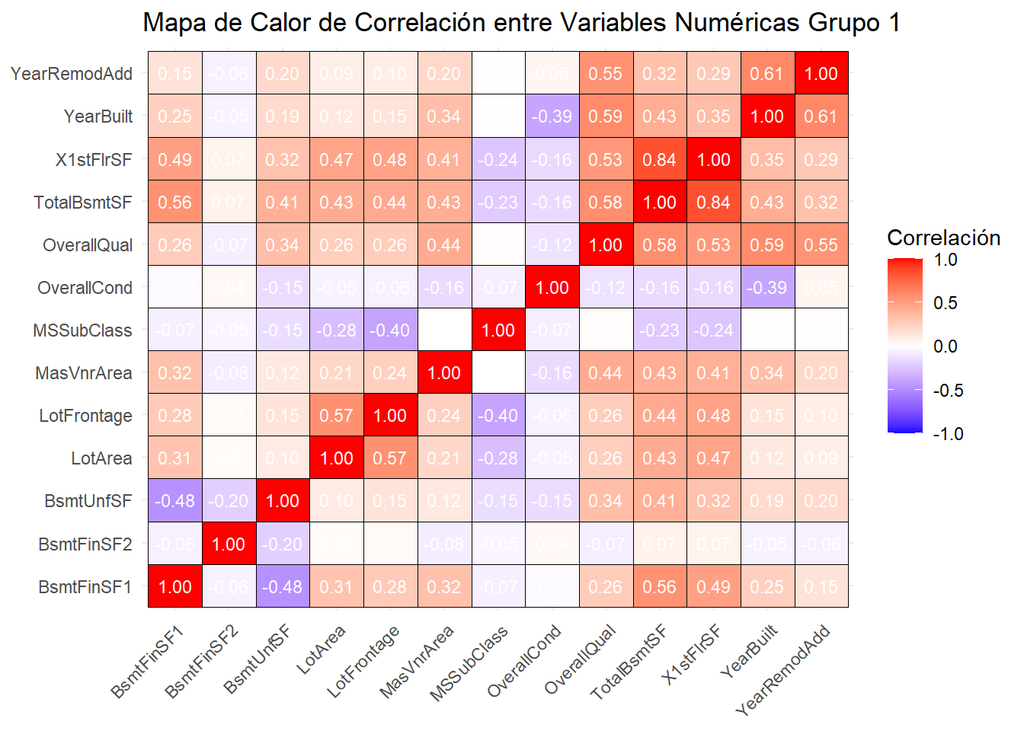

Dentro del Grupo 1, se destacan las fuertes correlaciones positivas entre variables como TotalBsmtSF (Superficie total del sótano) y 1stFlrSF (Superficie del primer piso), lo cual es esperado debido a su relación con el tamaño del área construida de la casa. Además, OverallQual (Calidad general) muestra correlaciones moderadas a fuertes con variables como YearBuilt (Año de construcción) y TotalBsmtSF, sugiriendo que la calidad general está relacionada tanto con la antigüedad de la propiedad como con sus características de tamaño.

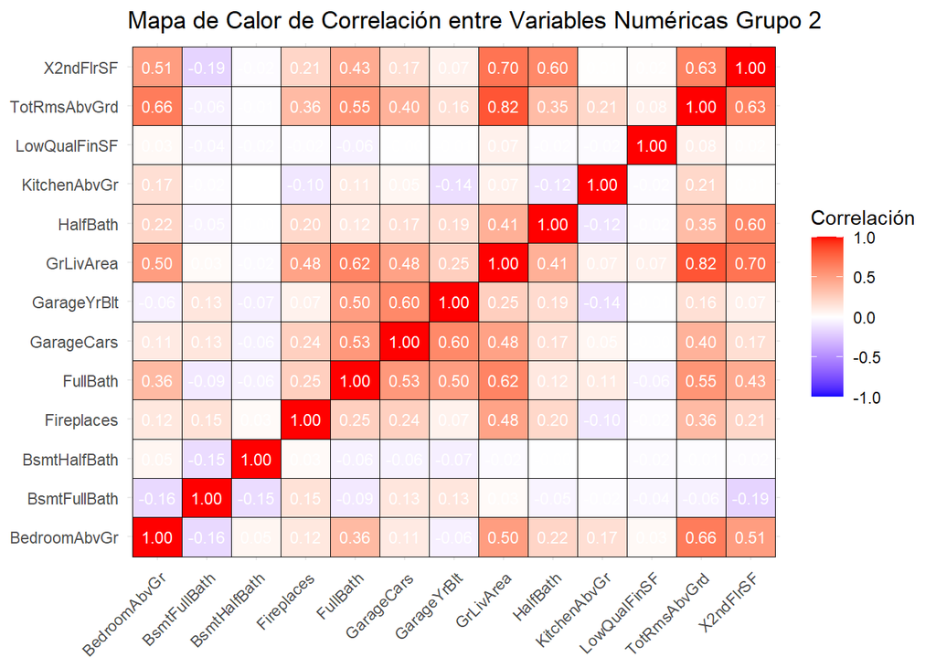

En el Grupo 2, las variables GrLivArea (Área habitable por encima del suelo) y TotRmsAbvGrd (Total de habitaciones por encima del suelo) presentan fuertes correlaciones positivas entre sí y con otras variables como BedroomAbvGr (Dormitorios por encima del suelo), lo que indica que las propiedades más grandes tienden a tener más habitaciones y dormitorios. Además, la correlación entre FullBath (Baños completos) y HalfBath (Medios baños) con GrLivArea resalta que las propiedades más amplias suelen contar con más instalaciones.

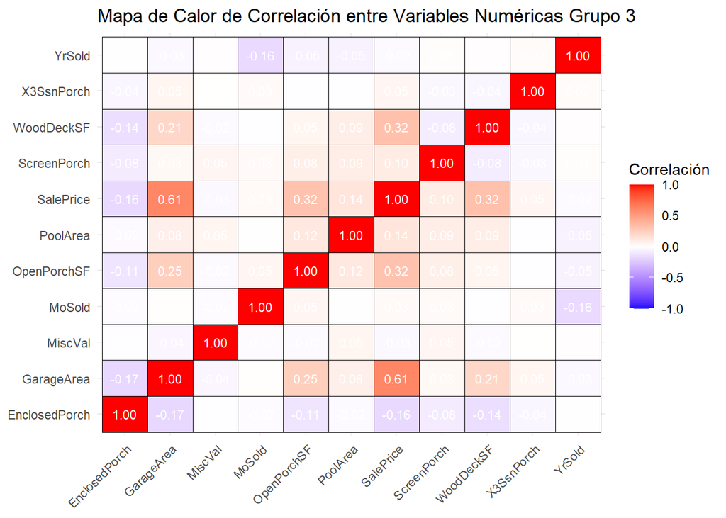

Finalmente, en el Grupo 3, variables como WoodDeckSF (Superficie de la terraza de madera) y OpenPorchSF (Superficie del porche abierto) no muestran correlaciones fuertes con muchas otras variables, lo que indica que estas características son relativamente independientes de otras medidas de tamaño o calidad general de la propiedad.

## Matriz de correlacion

Correlación de variables con SalePrice

| Correlacion | Variable |
| --- | --- |
| 1.0000000 | SalePrice |
| 0.7954824 | OverallQual |
| 0.6919415 | GrLivArea |
| 0.6459126 | GarageCars |
| 0.6201410 | TotalBsmtSF |
| 0.6198490 | X1stFlrSF |
| 0.6087580 | GarageArea |
| 0.5627985 | FullBath |
| 0.5456644 | TotRmsAbvGrd |
| 0.5250287 | YearBuilt |
| 0.5194382 | YearRemodAdd |
| 0.5190894 | GarageYrBlt |
| 0.4821325 | Fireplaces |
| 0.4760603 | MasVnrArea |
| 0.3893477 | BsmtFinSF1 |
| 0.3501135 | LotArea |
| 0.3489603 | LotFrontage |
| 0.3472972 | WoodDeckSF |
| 0.3274256 | OpenPorchSF |
| 0.2796509 | X2ndFlrSF |
| 0.2472716 | HalfBath |
| 0.2256583 | BsmtUnfSF |
| 0.2203791 | BsmtFullBath |
| -0.1759606 | EnclosedPorch |
| 0.1570178 | PoolArea |
| -0.1448286 | KitchenAbvGr |
| 0.1404005 | BedroomAbvGr |
| -0.1216658 | OverallCond |
| 0.0993296 | ScreenPorch |
| -0.0897462 | MSSubClass |
| -0.0518927 | MiscVal |
| 0.0438733 | X3SsnPorch |
| -0.0358929 | BsmtFinSF2 |
| 0.0247396 | MoSold |
| -0.0206356 | BsmtHalfBath |
| -0.0088647 | YrSold |
| -0.0000438 | LowQualFinSF |

Las variables con mayor correlación con `SalePrice` son `OverallQual` **(0.795)**, `GrLivArea` **(0.692)**, `GarageCars` **(0.646)** y `TotalBsmtSF` **(0.620)**. Estas indican que la calidad general de la vivienda, el área habitable, el tamaño del garaje y el área del sótano son los factores más influyentes en el precio. Otras variables como `FullBath`, `TotRmsAbvGrd` y `YearBuilt` también muestran correlaciones significativas, sugiriendo que características como el número de baños completos, habitaciones y la antigüedad de la vivienda son relevantes. Estas variables deberían ser prioritarias al construir el modelo de regresión lineal.

Por otro lado, variables como `Fireplaces`, `MasVnrArea` y `LotArea` tienen correlaciones moderadas (entre 0.3 y 0.5), lo que indica que, aunque aportan información, su impacto en el precio es menor. Características como `PoolArea`, `KitchenAbvGr` y `OverallCond` muestran correlaciones débiles o negativas, lo que sugiere que tienen poca influencia o, en algunos casos, podrían reducir el valor de la vivienda. Estas variables podrían omitirse para simplificar el modelo sin perder precisión.

### Prueba de hipotesis

Variables más importantes y su significancia

|  | Variable | Correlacion | P_Value |
| --- | --- | --- | --- |
| SalePrice | SalePrice | 1.0000000 | 0 |
| OverallQual | OverallQual | 0.7954824 | 0 |
| GrLivArea | GrLivArea | 0.6919415 | 0 |
| GarageCars | GarageCars | 0.6459126 | 0 |
| TotalBsmtSF | TotalBsmtSF | 0.6201410 | 0 |
| X1stFlrSF | X1stFlrSF | 0.6198490 | 0 |
| GarageArea | GarageArea | 0.6087580 | 0 |
| FullBath | FullBath | 0.5627985 | 0 |
| TotRmsAbvGrd | TotRmsAbvGrd | 0.5456644 | 0 |
| YearBuilt | YearBuilt | 0.5250287 | 0 |
| YearRemodAdd | YearRemodAdd | 0.5194382 | 0 |
| GarageYrBlt | GarageYrBlt | 0.5190894 | 0 |
| Fireplaces | Fireplaces | 0.4821325 | 0 |
| MasVnrArea | MasVnrArea | 0.4760603 | 0 |
| BsmtFinSF1 | BsmtFinSF1 | 0.3893477 | 0 |
| LotArea | LotArea | 0.3501135 | 0 |
| LotFrontage | LotFrontage | 0.3489603 | 0 |
| WoodDeckSF | WoodDeckSF | 0.3472972 | 0 |
| OpenPorchSF | OpenPorchSF | 0.3274256 | 0 |

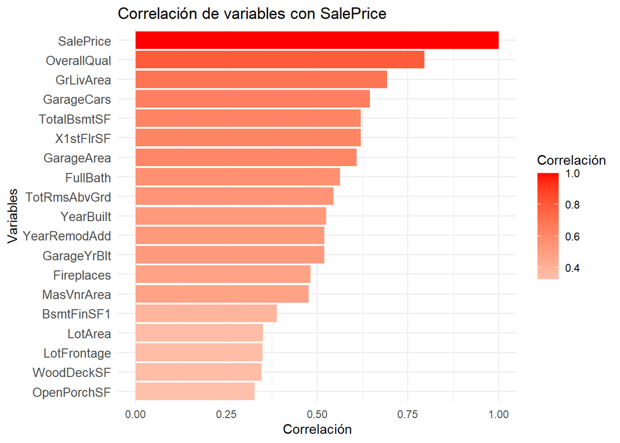

Por otro lado, variables como `MSSubClass`, `OverallCond` y `PoolArea` no cumplieron con los criterios de significancia o fuerza de correlación, por lo que podrían excluirse del modelo. Este filtrado ayuda a simplificar el análisis y mejorar la eficiencia del modelo al centrarse en las variables más relevantes.

## Variables Cualitativas

Variables Significativas con Efectos de Tamaño

| Variable | P_Value | Eta_Squared | Omega_Squared |
| --- | --- | --- | --- |
| LotConfig | 0.000245212427197998 | 0.0209760764227411 | -0.957125555012565 |
| Heating | 0.000713485891866415 | 0.0207281629661943 | -0.957619762674336 |
| Functional | 0.00288747144718382 | 0.0193942700673935 | -0.960282802253531 |
| BsmtFinType2 | 0.0119251537756486 | 0.0146755593473539 | -0.969683777138304 |
| MSSubClass | 0.0175249142403847 | 0.00552520597352651 | -0.987985381420279 |

Sin embargo, la presencia de valores negativos en Omega Squared para algunas variables sugiere que, en ciertos casos, el modelo no está capturando adecuadamente la relación entre las variables cualitativas y el precio de venta. Esto puede indicar que la variabilidad dentro de los grupos es mayor que entre ellos, lo que sugiere que estas variables pueden no ser tan relevantes para predecir el precio de venta como se pensaba inicialmente.